# #TidyTuesday 40 1.10.2019: All the Pizza

teofil

3/10/2019

# *Post hoc* synopsis

Втората значајна активност туке се однесува на користење на повеќе различни, но поврзани, табели за заедничко графирање. Типичен пример за ова е доколку сакаме да ги прикажеме сите податоци, но да го обрнеме вниманието на читателот на дел од податоците. Во вакви случаи вообичаено графираме еден слој (на пр., сиви точки) со сите податоци, и втор слој од обоени точки кои претставуваат накаква кондензација од сите податоци (средни вредности, суми, екстреми, итн.)

# Неопходни библиотеки

```r
library(tidyverse)
library(ggrepel)
library(ggpubr)
```

# Еден од датасетите за пица

```r
pizza_barstool <-
  readr::read_csv(
    "https://raw.githubusercontent.com/rfordatascience/tidytuesday/master/data/2019/2019-10-01/pizza_barstool.csv"
  )
```

Дефинираме некои бои за консистентно боење низ документот

```r
vv <- viridis::viridis(n = 9, alpha = .8, begin = .2 ,option = "C")[c(1,5,9)]
```

# Compare how pizzerias are rated by community vs. Dave

First grab just columns we need

```r
pzbs <-
  pizza_barstool %>%
  dplyr::select(name,
                address = address1,
                city,
                tidyselect::contains("average_score")) %>%
  filter(review_stats_community_average_score > 0)%>%
  filter(review_stats_dave_average_score > 0.2)
```

## Some more wrangling

Calculate the other two dataset that we created in the exploratory session. Color the pizzerias based on the degree of rating disagreement. First lets calculate the difference in rating.

```r
rate_diff <-
  pzbs %>%
  mutate(difference =
           review_stats_community_average_score - review_stats_dave_average_score)  %>%
  mutate(agreement=1/difference)
```

Highlight points (outliers, influential values,..). We need another dataset, this time for the five pizzerias with largest negative and positive difference.

```r
rate_diff_top5 <- rate_diff %>%
  mutate(pos_neg = ifelse(difference > 0, "preferred by community", "preferred by dave")) %>%
  group_by(pos_neg) %>%
  top_n(n = 5, wt = abs(difference)) %>%
  ungroup
```

More modifications to this data frame to make coordinates for segments for manual labels.

```r
rdt5 <-
  rate_diff_top5 %>%
  mutate(name_city= paste(name, "\n(", city, ")", sep="")) %>%
  select(name, name_city, contains("dave"), contains("community"), pos_neg, difference) %>%
  arrange(pos_neg, desc(difference)) %>%
  mutate(xend=c(rep(10.1,5), rep(2.4, 5))) %>%
  mutate(yend=c(5,2,3,4,6, 7,6,10,9,8)) %>%
  rename(x=review_stats_community_average_score,
         y=review_stats_dave_average_score)
```

## Now we should have everything to build the plot

### Geoms

```r
PP <-
  ggplot(data = pzbs) +
  geom_abline(slope = 1,
              intercept = 0,
              linetype = 2) +
  aes(x = review_stats_community_average_score) +
  aes(y = review_stats_dave_average_score) +
  geom_point(
    data = rate_diff,
    inherit.aes = TRUE,
    color = "white",
    aes(size = abs(difference), fill = difference),
    pch = 21
  ) +
  geom_segment(
    data = rdt5,
    size = .5,
    linetype = 3,
    aes(
      x = x,
      y = y,
      xend = xend,
      yend = yend
    )
  ) +
  geom_label(
    data = rdt5,
    aes(
      x = xend,
      y = yend,
      fill = difference,
      label = str_wrap(name, 22)
    ),
    size = 3.5,
    hjust = c(rep(0, 5), rep(1, 5))
  )
```

### Scales

```r
PP <- PP +
  scale_fill_gradient2(
    name = "",
    low = vv[1],
    mid = vv[2],
    high = vv[3],
    limits = c(-5, 7.5),
    breaks = c(-5,-2.5, 0, 2.5, 5, 7.5),
    labels = c(
      "Dave's favorites\nrated low by the community",
      "",
      "",
      "",
      "",
      "Community favorites\nrated low by Dave"
    ),
    guide = guide_colourbar(
      title.vjust = 1,
      frame.colour = 'white',
      label.position = "top",
      frame.linewidth = 1,
      ticks.colour = 'white',
      ticks.linewidth = 2,
      barheight = unit(.30, "cm"),
      barwidth = unit(8, "cm"),
      draw.ulim = TRUE,
      draw.llim = TRUE
    )
  ) +
  scale_y_continuous(breaks = seq(0, 10, 2), limits = c(0, 12)) +
  scale_x_continuous(breaks = seq(0, 10, 2), limits = c(0, 12)) +
  scale_size_continuous(range = c(0.5, 8), guide = "none")
```

### Labs

```r
PP <- PP +
  labs(x = "Community rating (average)") +
  labs(y = "Dave's rating") +
  labs(title = "Trust Dave?") +
  labs(subtitle = "Or follow the crowd?") +
  labs(caption = "TidyTuesdayAtKIKA using pizza_barstool data")
```

### Theme

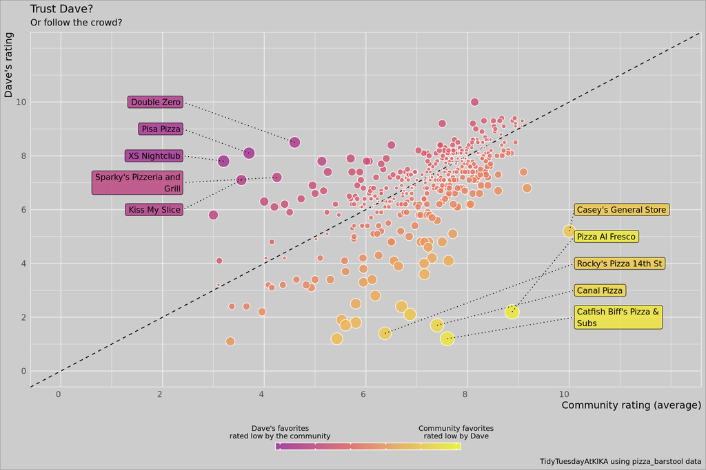

```r
PP <- PP +
  theme_minimal() +
  theme(legend.position = 'bottom') +
  theme(panel.background = element_rect(fill = "grey80", color = "white")) +
  theme(plot.background = element_rect(fill = "grey80", color = "grey60")) +
  theme(axis.title = element_text(hjust = 1, size = 12)) +
  theme(axis.text = element_text(hjust = 1, size = 10))

PP
```

# Other ways to label stuff

```r
 +
   geom_label_repel(
     data = rate_diff_top5, force=10,
     aes(x = review_stats_community_average_score,
         y = review_stats_dave_average_score,
         label = name,
         fill=difference),
     alpha=.8,
     inherit.aes = FALSE
   )
```

# Function to make fancy labels

```r
 library(ggforce)
 gmark <- function(row) {
   geom_mark_circle(
   data = row,
   label.fontsize = 8,
   label.fill = NA,
   aes(x = review_stats_community_average_score,
       y = review_stats_dave_average_score,
       label = name),
   inherit.aes = FALSE
 )
 }
PP + map(1:10, function(x) slice(rate_diff_top5, x) %>% gmark)
```